# Effective Campaigns in Bank Marketing

Identification of Factors Influencing Term Bank Deposit Decisions

Author: Mercy Atuahene

Date: April 16, 2025

# 1 Abstract

This analysis explores key factors influencing clients’ decisions to subscribe to a term deposit, using a real-world bank marketing dataset from a Portuguese financial institution. The dataset includes customer demographics, past contact history, and outcomes from previous marketing campaigns. The analysis also explores the effectiveness of classification models in prediction of customer subscription to term deposits. We utilized classification models and ensemble techniques to identify effective approach to marketing strategies. A series of exploratory data visualizations were used to identify patterns and relationships across variables such as job type, contact method, campaign timing, and prior campaign outcomes. Initial analyses using logistic regression and CART (Classification and Regression Trees) provided base insights with logistic regression achieving AUC = 0.6973, while CART models underperformed with an AUC ≈ 0.57. To improve performance, Bagging and Random Forest were implemented and tuned using grid search and cross-validation. Random Forest performed better with the highest AUC = 0.7026, possibly based on its strength in handling nonlinear relationships.

We further optimized classification cutoffs using cost-sensitive analysis and Youden’s index, accounting for the financial implications of misclassification. The results indicate that use of ensemble methods in predictive modeling of customer behavior is better than other classification meodels..

```r
#install.packages("readxl") # install package if required
#library(readr)
bank_orig <- read_delim("https://matuahene.github.io/STA552/Project3/bank.csv", delim = ";", quote = "\"")


#table (bank_orig$y)

#names(bank_orig) #smaller groups exist - student/unemployed/housemaid/enterpreneur

#table(bank_orig$marital) #divorced smaller
# table(bank_orig$education) #unknwon too small
# table(bank_orig$default) #less defaults
#
# table(bank_orig$housing)
# table(bank_orig$loan) #loan smaller
# table(bank_orig$contact) #telephone smaller
#
# table(bank_orig$month)
# table(bank_orig$campaign) #more people called at least 5X and quite few more than 14 times
# table(bank_orig$previous) #more not contact at least 1
# table(bank_orig$poutcome) #few sucess at a periouvs campgian
# table(bank_orig$y) #ffew succeess


#summary(bank_orig)
#describe(bank_orig)

#Function to Convert Variables to Factors with Labels
convert_to_factor <- function(df, var_labels) {
  for (var in names(var_labels)) {
    if (var %in% colnames(df)) {

      # Check if the variable has labels (list format) or is just a vector
      if (is.list(var_labels[[var]])) {
        labels <- var_labels[[var]]$labels   # Extract labels
        missing_values <- var_labels[[var]]$missing  # Extract missing values (if any)

        # Replace specified values with NA
        if (!is.null(missing_values)) {
          df[[var]][df[[var]] %in% missing_values] <- NA
        }
      } else {
        labels <- var_labels[[var]]  # Just a vector of labels
        missing_values <- NULL  # No missing values
      }

      # Convert to factor with labels (if labels exist)
      if (!is.null(labels)) {
        df[[var]] <- factor(df[[var]], labels = labels)
      } else {
        df[[var]] <- factor(df[[var]])  # Convert to factor without labels
      }

    } else {
      warning(paste("Variable", var, "not found in dataset"))
    }
  }
  return(df)
}

var_labels <- list(
  marital = c("divorced",  "married", "single "),
  education = c("primary", "secondary",  "tertiary", "unknown"),
  default = c("no", "yes"),
  housing = c("no", "yes"),
  loan = c("no", "yes"),
  contact = c("cellular", "telephone", "unknown"),

  month = c( "apr", "aug", "dec", "feb", "jan", "jul", "jun", "mar", "may", "nov", "oct", "sep"),
  pcoutcome = c("failure",   "other",  "success",  "unknown"),
  y = c("no", "yes")

  )


# Named list of labels
labels_list <- list(job = "Job",
                    marital = "Marital Status",
                    education = "Education",
                    age = "Age (years)",
                    defualt = "Defaulted?",
                   balance = "Average Yearly balance",
                   housing = "Mortgage",
                   loan = "Personal Loan?",
                   contact = "Communication Type",
                   day = "Last contact day of the month",
                   month = "Last contact month of year",
                   duration = "Last contact duration, in seconds",
                   campaign = "Number of contacts in campaign",
                   pdays = "Number of days passed since las contact",
                   previous = 'Number of previoous marketing campaign',
                   poutcome = 'Outcome of the previous marketing campaign',
                   y = 'Term Deposit Subscription'
)

#Assign labels from above to variables
bank_updt <- convert_to_factor(bank_orig, var_labels)


# Assign Labels to Variables Using table1::label()

library(table1)
for (var in names(labels_list)) {
  if (var %in% names(bank_updt)) {
    label(bank_updt[[var]]) <- labels_list[[var]]
  } else {
    warning(paste("Variable", var, "not found in dataset"))
  }
}


#put month in order
bank_updt$month <- factor(bank_updt$month,
                          levels = c("jan", "feb", "mar", "apr", "may", "jun",
                                     "jul", "aug", "sep", "oct", "nov", "dec"),
                          ordered = TRUE)

library(dplyr)

bank_updt <- bank_updt %>%
  mutate(season = case_when(
    month %in% c("mar", "apr", "may") ~ "Spring",
    month %in% c("jun", "jul", "aug") ~ "Summer",
    month %in% c("sep", "oct", "nov") ~ "Fall",
    month %in% c("dec", "jan", "feb") ~ "Winter",
    TRUE ~ NA_character_
  ))

bank_updt$season <- factor(bank_updt$season,
                           levels = c("Winter", "Spring", "Summer", "Fall"))
```

# 2 Introduction

Mass campaigns or direct marketing targeting consumers are widely known to have a low response rate (Ling and Li, 1998). Banks and other financial institutions seek ways to improve their response rate in marketing their products to consumers. Targetted or Directed marketing is one of the efficient ways to marget products due to its efficiency property (Ou et al. 2003) irrespective of some of its negative impacts.To encourage asset building banks may use direct or target approaches to attrach individuals likely interested in a bank product that promises interests over time. However targetted or direct campaigns are laboriuous and not efficient if multiple contacts has to be made for a product to be sold. This opens up the question of how to implement measures that are efficient and still gets the product to clients in the banking industry in a way that minimizes resources utilization and still gets the product across. Specifically, can we use bank customer information to predict who is likely to purchase a campaign product after initiation of direct contact?

With this background, we will use data from a Portuguese Bank created by *“Paulo Cortez (Univ. Minho) and Sérgio Moro (ISCTE-IUL) @ 2012. The data is related with direct marketing campaigns of a Portuguese banking institution. The marketing campaigns were based on phone calls. Often, more than one contact to the same client was required, in order to access if the product (bank term deposit) would be (or not) subscribed”*. This data can be located at [(Bank Marketing)](https://archive.ics.uci.edu/dataset/222/bank+marketing) .

Our aim is to use classification and regression tree (CART), ensemble: Bagging and Random Forest (RF) approaches to build algorithms that helps predict bank customers who would subscribe to the campaign product (a term deposit). We would use respondents data such as age, average yearly balance, contact duration, marital status, etc, to discriminate respondents likelihood to subscribe to the term deposit product. We would also use regression tree approach to determine variables that impact average yearly balance at the bank based on participants factors when possible considering time restraints for the project.

We will first use classification Trees (of the CART methods) to predict customers subscribing to the campaign product (term deposit) or not. We will also use Regression Trees to predict the amount of yearly balance (euros) in a customer’s account using respondents characteristics. Additional models will utilize the ebsemble techniques Bagging and RF. The model performance of these approaches will be conpared using appropriate perfomance measures like AUC and accuracy when applicable.

# 3 Data Overview

## 3.2 Feature and Target Variables

- **Target variable:**
- y : Subscription to Term deposit. Client subscribed a term deposit? (binary: “yes”,“no”)
- **Independent feature variables**
- age (numeric) in years
- job : type of job (categorical: “admin.”,“unknown”,“unemployed”,“management”,“housemaid”,“entrepreneur”,“student”, “blue-collar”,“self-employed”,“retired”,“technician”,“services”)
- marital : marital status (categorical: “married”,“divorced”,“single”; note: “divorced” means divorced or widowed)
- education (categorical: “unknown”,“secondary”,“primary”,“tertiary”)
- default: has credit in default? (binary: “yes”,“no”)
- balance: average yearly balance, in euros (numeric)
- housing: has housing loan? (binary: “yes”,“no”)
- loan: has personal loan? (binary: “yes”,“no”)
- contact: contact communication type (categorical: “unknown”,“telephone”,“cellular”)
- day: last contact day of the month (numeric)
- month: last contact month of year (categorical: “jan”, “feb”, “mar”, …, “nov”, “dec”)
- duration: last contact duration, in seconds (numeric)
- campaign: number of contacts performed during this campaign and for this client (numeric, includes last contact)
- pdays: number of days that passed by after the client was last contacted from a previous campaign (numeric, -1 means client was not previously contacted)
- previous: number of contacts performed before this campaign and for this client (numeric)
- poutcome: outcome of the previous marketing campaign (categorical: “unknown”,“other”,“failure”,“success”)

## 3.3 Descriptive Statistics/Graphs/Fetaure engineering

We provide descriptive statistics in addition to explorative data analysis of the bank client data next.We begin with an overall Table of feature variables by Termd Deposit Subscription status.

```r
library(table1)
library(gt)


bank_demo<-table1(
  ~ age + job + marital + education + default + balance + housing + loan +
    contact + day + month + duration + campaign + pdays + previous + poutcome | y,
  data = bank_updt,
  caption = "Table 1: Descriptive Statistics Stratified by Client Term Deposit Subscription",
  footnote = "Data source: Portuguese Client Bank Dataset",
  topclass = "Rtable1-modern"

)
bank_demo
```

Table 1: Descriptive Statistics Stratified by Client Term Deposit Subscription

|  | no (N=4000) | yes (N=521) | Overall (N=4521) |
| --- | --- | --- | --- |
| Age (years) |  |  |  |
| Mean (SD) | 41.0 (10.2) | 42.5 (13.1) | 41.2 (10.6) |
| Median [Min, Max] | 39.0 [19.0, 86.0] | 40.0 [19.0, 87.0] | 39.0 [19.0, 87.0] |
| Job |  |  |  |
| admin. | 420 (10.5%) | 58 (11.1%) | 478 (10.6%) |
| blue-collar | 877 (21.9%) | 69 (13.2%) | 946 (20.9%) |
| entrepreneur | 153 (3.8%) | 15 (2.9%) | 168 (3.7%) |
| housemaid | 98 (2.5%) | 14 (2.7%) | 112 (2.5%) |
| management | 838 (21.0%) | 131 (25.1%) | 969 (21.4%) |
| retired | 176 (4.4%) | 54 (10.4%) | 230 (5.1%) |
| self-employed | 163 (4.1%) | 20 (3.8%) | 183 (4.0%) |
| services | 379 (9.5%) | 38 (7.3%) | 417 (9.2%) |
| student | 65 (1.6%) | 19 (3.6%) | 84 (1.9%) |
| technician | 685 (17.1%) | 83 (15.9%) | 768 (17.0%) |
| unemployed | 115 (2.9%) | 13 (2.5%) | 128 (2.8%) |
| unknown | 31 (0.8%) | 7 (1.3%) | 38 (0.8%) |
| Marital Status |  |  |  |
| divorced | 451 (11.3%) | 77 (14.8%) | 528 (11.7%) |
| married | 2520 (63.0%) | 277 (53.2%) | 2797 (61.9%) |
| single | 1029 (25.7%) | 167 (32.1%) | 1196 (26.5%) |
| Education |  |  |  |
| primary | 614 (15.4%) | 64 (12.3%) | 678 (15.0%) |
| secondary | 2061 (51.5%) | 245 (47.0%) | 2306 (51.0%) |
| tertiary | 1157 (28.9%) | 193 (37.0%) | 1350 (29.9%) |
| unknown | 168 (4.2%) | 19 (3.6%) | 187 (4.1%) |
| default |  |  |  |
| no | 3933 (98.3%) | 512 (98.3%) | 4445 (98.3%) |
| yes | 67 (1.7%) | 9 (1.7%) | 76 (1.7%) |
| Average Yearly balance |  |  |  |
| Mean (SD) | 1400 (3080) | 1570 (2440) | 1420 (3010) |
| Median [Min, Max] | 420 [-3310, 71200] | 710 [-1210, 27000] | 444 [-3310, 71200] |
| Mortgage |  |  |  |
| no | 1661 (41.5%) | 301 (57.8%) | 1962 (43.4%) |
| yes | 2339 (58.5%) | 220 (42.2%) | 2559 (56.6%) |
| Personal Loan? |  |  |  |
| no | 3352 (83.8%) | 478 (91.7%) | 3830 (84.7%) |
| yes | 648 (16.2%) | 43 (8.3%) | 691 (15.3%) |
| Communication Type |  |  |  |
| cellular | 2480 (62.0%) | 416 (79.8%) | 2896 (64.1%) |
| telephone | 257 (6.4%) | 44 (8.4%) | 301 (6.7%) |
| unknown | 1263 (31.6%) | 61 (11.7%) | 1324 (29.3%) |
| Last contact day of the month |  |  |  |
| Mean (SD) | 15.9 (8.25) | 15.7 (8.24) | 15.9 (8.25) |
| Median [Min, Max] | 16.0 [1.00, 31.0] | 15.0 [1.00, 31.0] | 16.0 [1.00, 31.0] |
| month |  |  |  |
| jan | 132 (3.3%) | 16 (3.1%) | 148 (3.3%) |
| feb | 184 (4.6%) | 38 (7.3%) | 222 (4.9%) |
| mar | 28 (0.7%) | 21 (4.0%) | 49 (1.1%) |
| apr | 237 (5.9%) | 56 (10.7%) | 293 (6.5%) |
| may | 1305 (32.6%) | 93 (17.9%) | 1398 (30.9%) |
| jun | 476 (11.9%) | 55 (10.6%) | 531 (11.7%) |
| jul | 645 (16.1%) | 61 (11.7%) | 706 (15.6%) |
| aug | 554 (13.9%) | 79 (15.2%) | 633 (14.0%) |
| sep | 35 (0.9%) | 17 (3.3%) | 52 (1.2%) |
| oct | 43 (1.1%) | 37 (7.1%) | 80 (1.8%) |
| nov | 350 (8.8%) | 39 (7.5%) | 389 (8.6%) |
| dec | 11 (0.3%) | 9 (1.7%) | 20 (0.4%) |
| Last contact duration, in seconds |  |  |  |
| Mean (SD) | 226 (210) | 553 (390) | 264 (260) |
| Median [Min, Max] | 167 [4.00, 3030] | 442 [30.0, 2770] | 185 [4.00, 3030] |
| Number of contacts in campaign |  |  |  |
| Mean (SD) | 2.86 (3.21) | 2.27 (2.09) | 2.79 (3.11) |
| Median [Min, Max] | 2.00 [1.00, 50.0] | 2.00 [1.00, 24.0] | 2.00 [1.00, 50.0] |
| Number of days passed since las contact |  |  |  |
| Mean (SD) | 36.0 (96.3) | 68.6 (122) | 39.8 (100) |
| Median [Min, Max] | -1.00 [-1.00, 871] | -1.00 [-1.00, 804] | -1.00 [-1.00, 871] |
| Number of previoous marketing campaign |  |  |  |
| Mean (SD) | 0.471 (1.63) | 1.09 (2.06) | 0.543 (1.69) |
| Median [Min, Max] | 0 [0, 25.0] | 0 [0, 14.0] | 0 [0, 25.0] |
| Outcome of the previous marketing campaign |  |  |  |
| failure | 427 (10.7%) | 63 (12.1%) | 490 (10.8%) |
| other | 159 (4.0%) | 38 (7.3%) | 197 (4.4%) |
| success | 46 (1.2%) | 83 (15.9%) | 129 (2.9%) |
| unknown | 3368 (84.2%) | 337 (64.7%) | 3705 (82.0%) |

Data source: Portuguese Client Bank Dataset

```r
#table(bank_updt$month)
```

```r
kable(bank_demo, caption = "Table 1:  Descriptive Statistics Stratified by Client Subscription")
```

In Table 1, we notice client demographics vary by subscription status. Balance (average yearly in euros) is higher among those subscribed to a term depost compared to those who did not. The median value was also less than the mean indicating a right skewed data.There were extreme negative and positive balance. In the previous campaigns(poutcome), there were more people who subscribed(15.9%) than those who did not (1.2%) sign up thoughly only 2.9% overall success rate was achieved. In previous campaigns (previous), more people on average were contacted from those who signed up for the current campaign than those who did not. Age was also positively skewed but since CART does not require features to be transformed or normalized, we will only bin variables with extremes. We will instead bin age into balanced into equal bins to improve interpretability, reduce over fitting to extreme values and improve performance of the non-CART models for comparison. The log or other transformations like Box-Cox or Yue-Johnson will be used as necessary when comparing with other models like logistic regression where feature transformation is necessary. The number of days since last contact was aldo engineered by binning the values into quadrilles to avoid overfitting.

```r
# library(bestNormalize)
# yj_age <- yeojohnson(bank_orig$age)
# bank_orig$logage<- log(bank_orig$age)
# bank_orig$age_yj <- yj_age$x.t
# hist(bank_orig$age_yj, main = "Yeo-Johnson Transformed Age")
# hist(bank_orig$age, main = "original Age")
# hist(bank_orig$logage, main = "log Age")

#library(moments)
#check skewness after trrasnformations
#skewness(bank_orig$age, na.rm = TRUE)
#skewness(bank_orig$logage, na.rm = TRUE)
#skewness(bank_orig$age_yj)
```

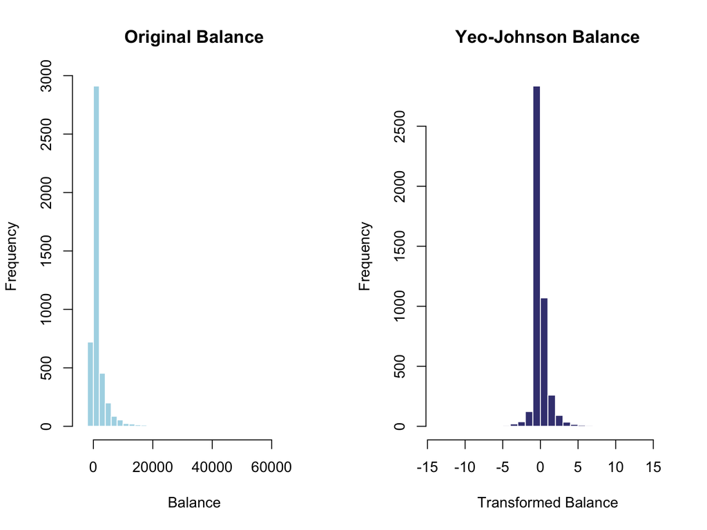

```r
#library(haven)
#library(skimr)
# Remove value labels (but retain variable labels used by table1)
#bank_updt_clean <- bank_updt %>%
#mutate(across(where(~ inherits(.x, "labelled")), haven::zap_labels))


#balance conversion via log
bank_updt$log_balance <- log1p(bank_updt$balance)

#summary(bank_updt$balance)
#summary(bank_updt$log_balance)

# Load library trasnformation
library(bestNormalize)

# 1. Apply Yeo-Johnson transformation
yj_balance <- yeojohnson(bank_updt$balance)

# 2. Store the transformed values
bank_updt$balance_yj <- yj_balance$x.t

# 3. Print lambda (optional)
#print(yj_balance$lambda)

# 4. Plot original vs transformed histograms with colors
par(mfrow = c(1, 2))  # side-by-side plots

# Original Balance Plot
hist(bank_updt$balance,
     breaks = 30,
     col = "lightblue",
     border = "white",
     main = "Original Balance",
     xlab = "Balance")

# Transformed Balance Plot
hist(bank_updt$balance_yj,
     breaks = 30,
     col = "#404080",
     border = "white",
     main = "Yeo-Johnson Balance",
     xlab = "Transformed Balance")
```

```r
#Quartile of age
bank_updt$age_quantile <- cut(
  bank_updt$age,
  breaks = quantile(bank_updt$age, probs = seq(0, 1, 0.25), na.rm = TRUE),
  include.lowest = TRUE,
  labels = c("Q1", "Q2", "Q3", "Q4")
)

#Quartile of balance
bank_updt$balance_quantile <- cut(
  bank_updt$balance,
  breaks = quantile(bank_updt$balance, probs = seq(0, 1, 0.25), na.rm = TRUE),
  include.lowest = TRUE,
  labels = c("Q1", "Q2", "Q3", "Q4")
)

#table(bank_updt$age_quantile)
#table(bank_updt$balance_quantile)

#number of days since previous contact quartiles
bank_updt <- bank_updt %>%
  mutate(pdays_quantile = ntile(pdays, 4))  # 4 = quartiles
```

Next, we show additional graphical distributions of the relations existing among the features for further exploratory analysis.The density plots showed other features that were skewed.

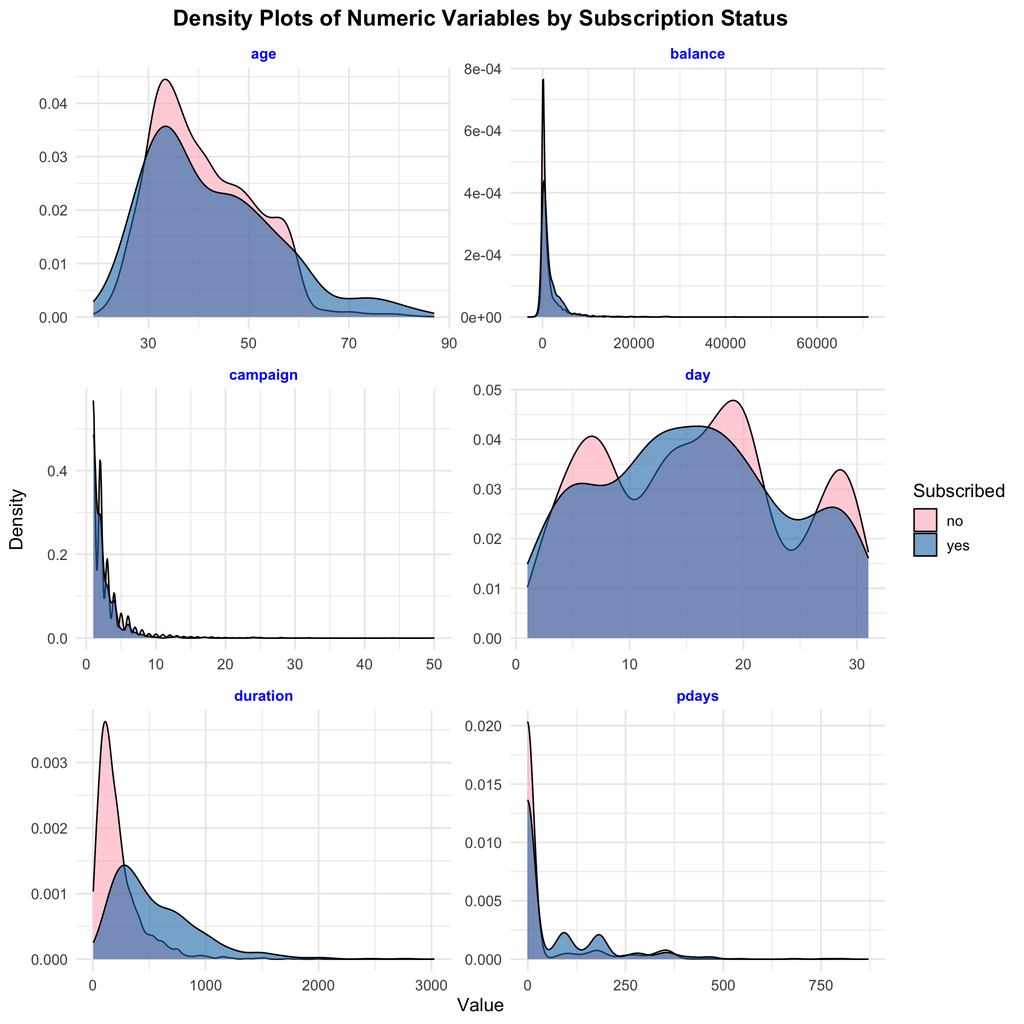

Figure 3.2: Density Plots of Numeric Variables by Subscription Status

```r
library(ggplot2)
library(dplyr)
library(tidyr)

#numeric variables density plots
# Prepare the data in long format
num_vars <- bank_orig %>%
  dplyr::select(y, age, balance, duration, campaign, pdays, day) %>%
  pivot_longer(cols = -y, names_to = "variable", values_to = "value")

# Create faceted density plot
ggplot(num_vars, aes(x = value, fill = y)) +
  geom_density(alpha = 0.6) +
  scale_fill_manual(values = c("yes" = "#1f77b4", "no" = "lightpink")) +
  facet_wrap(~variable, scales = "free", ncol = 2) +
  theme_minimal(base_size = 13) +
  labs(
    title = "Density Plots of Numeric Variables by Subscription Status",
    x = "Value",
    y = "Density",
    fill = "Subscribed"
  ) +
  theme(
    strip.text = element_text(face = "bold", color = "blue"),
    plot.title = element_text(face = "bold", hjust = 0.5)
  )
```

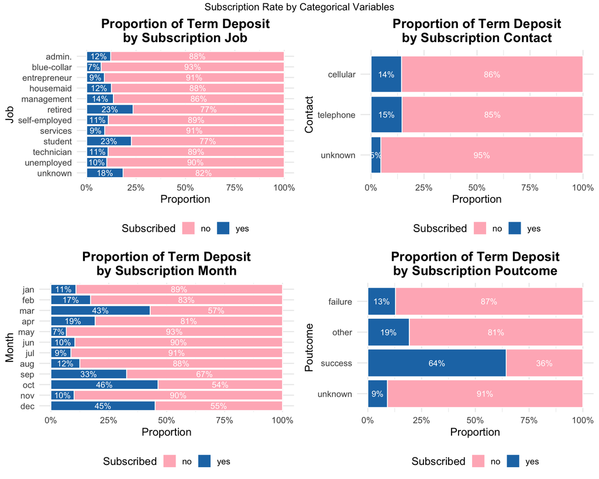

Figure 3.3: Categorical Feature Plots by Subscription Status

```r
library(ggplot2)
library(dplyr)
library(forcats)
library(gridExtra)

# Your categorical variables
cat_vars <- c("job", "contact", "month", "poutcome")

# Initialize plot list
cat_plots <- list()

# Loop through each categorical variable
for (var in cat_vars) {

  # Step 1: Calculate proportions for this variable
  prop_df <- bank_updt %>%
    count(.data[[var]], y, name = "n") %>%
    group_by(.data[[var]]) %>%
    mutate(prop = n / sum(n)) %>%
    ungroup()

  # Optional: Rename the variable to "Category" so ggplot can use it
  prop_df <- prop_df %>% rename(Category = !!sym(var))

  # Step 2: Create plot
  p <- ggplot(prop_df, aes(x = fct_rev(Category), y = prop, fill = y)) +
    geom_bar(stat = "identity", position = "stack", color = "white") +
    geom_text(
      aes(label = scales::percent(prop, accuracy = 1)),
      position = position_stack(vjust = 0.5),
      color = "white",
      size = 3.5
    ) +
    scale_y_continuous(labels = scales::percent) +
    scale_fill_manual(values = c("no" = "lightpink", "yes" = "#1f77b4")) +
    coord_flip() +
    theme_minimal(base_size = 13) +
    labs(
      title = paste("Proportion of Term Deposit\nby Subscription", tools::toTitleCase(var)),
      x = tools::toTitleCase(var),
      y = "Proportion",
      fill = "Subscribed"
    ) +
    theme(
      plot.title = element_text(face = "bold", hjust = 0.5),
      legend.position = "bottom"
    )

  # Save to list
  cat_plots[[var]] <- p
}

# Show all plots (adjust ncol/nrow as needed)
grid.arrange(grobs = cat_plots, ncol = 2, top = "Subscription Rate by Categorical Variables")
```

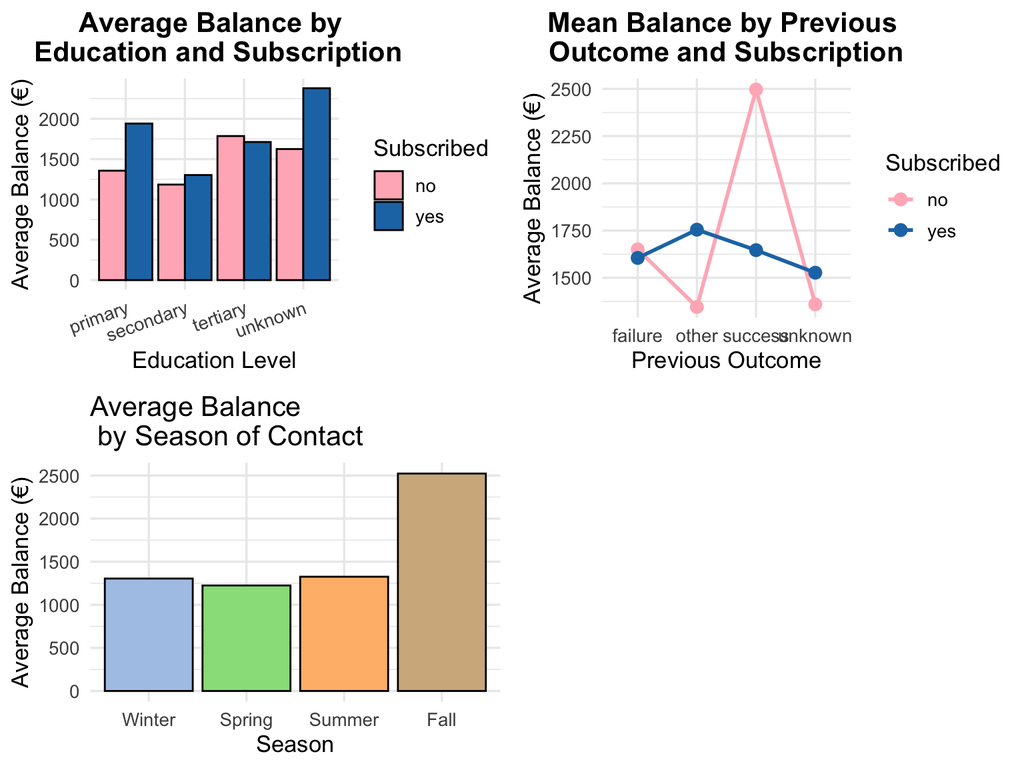

Figure 3.4: Additional Feature Plots by Subscription Status

```r
education<-ggplot(bank_updt, aes(x = education, y = balance, fill = y)) +
  stat_summary(fun = "mean", geom = "col", position = "dodge", color = "black") +
  scale_fill_manual(values = c("yes" = "#1f77b4", "no" = "lightpink")) +  # Custom fill colors
  theme_minimal(base_size = 13) +
  labs(
    title = "Average Balance by \n Education and Subscription",
    x = "Education Level",
    y = "Average Balance (€)",
    fill = "Subscribed"
  ) +
  theme(
    plot.title = element_text(face = "bold", hjust = 0.5),
    axis.text.x = element_text(angle = 20, hjust = 1)
  )


library(dplyr)
library(dplyr)
library(ggplot2)

Mean_bal <- bank_updt %>%
  group_by(poutcome, y) %>%
  summarise(mean_balance = mean(balance, na.rm = TRUE), .groups = "drop") %>%
  ggplot(aes(x = poutcome, y = mean_balance, group = y, color = y)) +
  geom_line(size = 1) +
  geom_point(size = 3) +
  scale_color_manual(values = c("yes" = "#1f77b4", "no" = "lightpink")) +  # custom colors
  theme_minimal(base_size = 13) +
  labs(
    title = "Mean Balance by Previous \nOutcome and Subscription",
    x = "Previous Outcome",
    y = "Average Balance (€)",
    color = "Subscribed"
  ) +
  theme(
    plot.title = element_text(face = "bold", hjust = 0.5)
  )




season2<-ggplot(bank_updt, aes(x = season, y = balance, fill = season)) +
  stat_summary(fun = "mean", geom = "col", color = "black") +
  #scale_fill_brewer(palette = "Set2")
  scale_fill_manual(values = c(
  "Winter" = "#aec7e8",   # blue
  "Spring" = "#98df8a",   # green
  "Summer" = "#ffbb78",   # orange
  "Fall"   = "#d2b48c"    # brown
))+
  theme_minimal(base_size = 13) +
  labs(
    title = "Average Balance \n by Season of Contact",
    x = "Season",
    y = "Average Balance (€)"
  ) +
  theme(legend.position = "none")


grid.arrange(education, Mean_bal,season2, ncol=2)
```

# 4 Methodology

## 4.1 Methodological Comparisons

With respect to our aim of identifying factors that influence subscription to term deposits, we summarize and evaluate alternative methods beyond the CART model that could contribute to our analysis. We discuss the Logistic regression, Support Vectoer Machines and ensemble methods and our method of CART regression.

- **Logistic Regression: Logistic regression** models the probability that a customer will subscribe to a term deposit based on on our feature variables and generates coefficients and probability of subscribing to term deposits. Since logistic regression assumes linearity between features and log-odd of the target, it is not good for complex and non-linear relationships. Feature engineering is often needed to improve the model fit.
- **Classification (Decision) and Regression Tress (CART)**: CART models on the otherhand, provides a transparent way to classify customers into “yes” or “no” subscription groups by splitting the data based on important features.They handle both categorical and continuous variables effectively and are well suited for detecting non-linear relations. The CART models may however, over fit when there is data imbalance unless there is there is pre or post-pruning to its complexity.
- **Support Vector Machines (SVM)**: Support Vector Machines aim to find the best boundary or hyperplane that separates the target into classes from low to high-dimensional space using kernel functions to allow for complex patterns in the data to be modeled. It is known to work well with high dimensional data and also for non-linear boundaries and are robust against over-fitting. However, the tuning component makes the approach sensitive and also not easy to interpret and require feature engineering to improve model fit.
- **Random Forests (RF)**: is an ensemble machine learning algorithm that is used for both classification and regression. It is is based on building multiple CART algorithms and combining their predictions to produce a more robust, accurate and stable result than that obtained from a single tree. By using multiple tress,s RF reduces overfitting unlike that from a single Tree which can easily overfit. Since it pools results from multiple trees, the approach is less sensitive to noisy data. But this also means, it can be memory intensive and slower since they could be multiple trees during training and predictions.
- **Bagging**: This method is also called Bootstrap aggregating similar to the RF idea. It is an ensemble learning technique that improves the accuracy and stability of machine learning models. It is also effective in decision trees and reduces overfitting and variance by training multiple versions of a model on different random subsets of the data and aggregating their predictions. It can also be computationally expensive due to the pooling of results from multiple models.

## 4.2 Classification Tree: Predicting Term Deposit

We will now use classification tree to predict term deposit subscription following a campaign, then we will compare this model to the traditional logistic regression or our base model and compare the Classification Tree model predictive performance. We will pass a loss matrix to our tree model to handle classifications. This will be in addition to other hyper parameters for performance measures and splitting using the gini index.

We excluded duration in our model since ideally, we will not know if a customer will sign up or not since duration will only be available after contacting the customer and cannot be used to predict if a customer signs up or not. This will avoid over performance of the model since duration at prediction will not be known in future predictions.

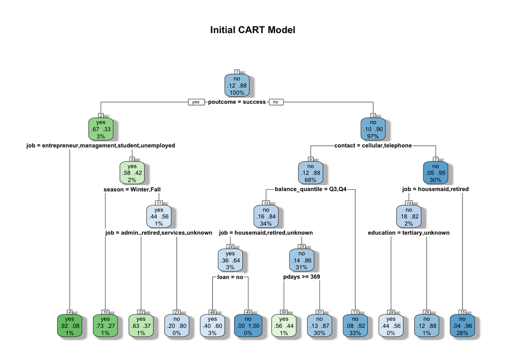

```r
 library(rpart)        # For decision trees
 library(rpart.plot)   # For visualizing trees
 library(caret)        # For model evaluation
 library(pROC)         # For ROC analysis

#names(bank_orig)
#data for RF classification - excluding duration
class_data <-bank_updt[, c("y", "season", "balance_quantile", "age_quantile", "job", "marital", "education","contact", "poutcome","previous",
                           "default", "pdays" , "day","campaign", "housing" , "loan")]
#str(bank_orig)
# Split data into training (70%) and test (30%) sets
set.seed(778)
train.index <- createDataPartition(class_data$y, p = 0.7, list = FALSE)
train.data <- class_data[train.index, ]
test.data <- class_data[-train.index, ]

#making sure yes is first
#levels(test.data$y)
train.data$y <- factor(train.data$y, levels = c("yes", "no"))
test.data$y <- factor(test.data$y, levels = c("yes", "no"))
#levels(test.data$y)


# Build the initial classification tree
tree.model <- rpart(y ~ . ,
                    data = train.data,
                    method = "class",   # classification tree
                    parms = list(split = "gini",  # Using Gini index
                                 # FN cost = 1, FP cost = 0.5
                                 loss = matrix(c(0, 0.5, 1, 0), nrow = 2)
                                 ),
                    control = rpart.control(minsplit = 15,  # Min 15 obs to split
                                           minbucket = 7,   # Min 7 obs in leaf
                                           # Complexity parameter
                                           cp = 0.001, # complex parameter
                                           maxdepth = 5))   # Max tree depth

rpart.plot(tree.model,
           extra = 104, # check the help document for more information
           # color palette is a sequential color scheme that blends green (G) to blue (Bu)
           box.palette = "GnBu",
           branch.lty = 1,
           shadow.col = "gray",
           nn = TRUE,
           main = "Initial CART Model")
```

### 4.2.1 Interpretation of the Initial CART Model

The decision tree begins with the most significant variable: poutcome = success; which is the outcome of a previous marketing campaign. This split, immediately separates the population based on whether a customer had a successful prior interaction, indicating that past success in marketing efforts is the strongest predictor of subscription.The model suggests that prior marketing success, job type, season of contact, and client history (e.g., pdays, balance) are key drivers of subscription decisions. However, the complexity (using the number of splits or nodes) of the tree implies the need for pruning or cross-validation to avoid overfitting and ensure that the model performs well on unseen data. Next, we show the variable importance via a plot.

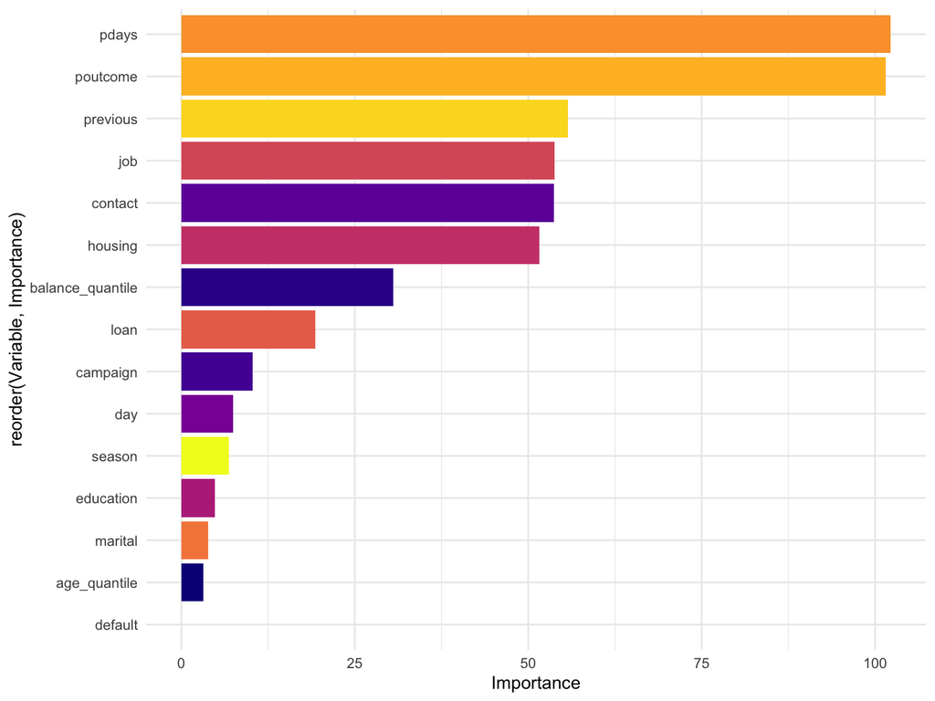

Figure 4.1: Variable Importance from Initial CART Model

```r
library(ggplot2)
library(viridis)

#variable importance
#varImp(tree.model)

# Extract importance
importance <- as.data.frame(varImp(tree.model))

# Add variable names as a column
importance$Variable <- rownames(importance)

# Rename for clarity
colnames(importance)[1] <- "Importance"



ggplot(importance, aes(x = reorder(Variable, Importance), y = Importance, fill = Variable)) +
  geom_bar(stat = "identity") +
  coord_flip() +
  scale_fill_viridis_d(option = "plasma") +
  theme_minimal() +
  theme(legend.position = "none")
```

```r
top_vars <- importance %>% top_n(10, Importance)
#top_vars
```

**Figure 4.1** shows that prior campaign interactions (pdays, poutcome and previous) were the most influential predictors of term deposit subscription. Socioeconomic factors like job and contact also had moderate influence, while demographic variables such as education, marital status, and default showed limited predictive utility in this model.

The initial tree based on the hyperparamters (minsplit, minbucket, cp and max depth) is shown above. Next we use post pruning on the original model via cross-validation to select an optimal complexity parameter (cp), that chooses the cp value that minimizes cross-validation error (xerror), or applying the 1-SE rule - selecting the largest cp where xerror ≤ (min xerror + 1 standard error) to balance model complexity and predictive performance. The complexity parameter(cp) penalizes the number of splits where a lower cp allows for more plots and a higher cp restricts not so useful complexity.

```r
# Print the complexity parameter table
#pander(tree.model$cptable)
library(knitr)
library(kableExtra)

# Extract the CP table
cp_table <- as.data.frame(tree.model$cptable)

#caption = "Table: Complexity Parameter Table for CART Model"
# Display with title
cp_tab <-kable(cp_table ) %>%
  kable_styling(full_width = TRUE, position = "left")
```

```r
kable(as.data.frame(tree.model$cptable), caption = "Table 2: Complexity Parameter Table for CART Model")
```

Table 4.1: Table 2: Complexity Parameter Table for CART Model

| CP | nsplit | rel error | xerror | xstd |
| --- | --- | --- | --- | --- |
| 0.1219178 | 0 | 1.0000000 | 0.5000000 | 0.0246159 |
| 0.0082192 | 1 | 0.8780822 | 0.4986301 | 0.0267084 |
| 0.0027397 | 6 | 0.8369863 | 0.6136986 | 0.0324338 |
| 0.0020548 | 9 | 0.8287671 | 0.6424658 | 0.0335407 |
| 0.0010000 | 11 | 0.8246575 | 0.6356164 | 0.0332167 |

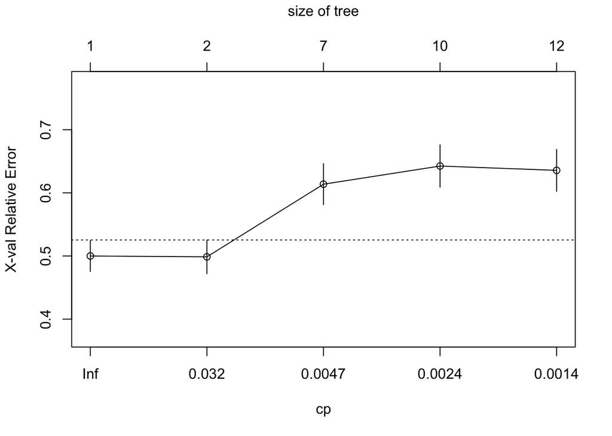

```r
plotcp(tree.model)
```

### 4.2.2 Tree Pruning

From the cross validation complexity plot in choosing the best cp, we see that the minimum error is around cp ≈ 0.032 and only 2 splits which achieves an error within 1-SE of the minimum. Any other splitting increases the error at cp ≈ 0.0047 or 0.0024. Next we will prune the original model using the 1-SE rule.This pruned model is likely to generalize better and reduce overfitting.

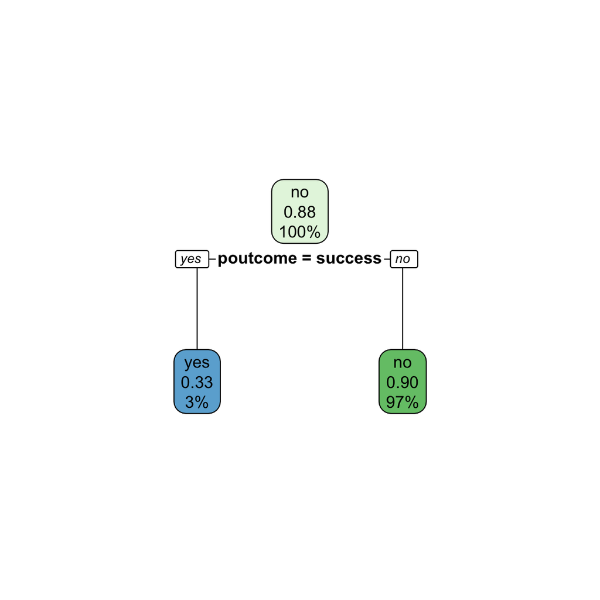

Figure 4.2: Pruned CART model using minimum cross-validation error (CP = 0.0082). The tree identifies poutcome = success as the only significant split for predicting term deposit subscription.

```r
# Use the CP value that minimizes cross-validated error
best_cp <- tree.model$cptable[which.min(tree.model$cptable[,"xerror"]), "CP"]
#best_cp #use exact value from tree.model$cptable

pruned_tree <- prune(tree.model, cp = best_cp)
rpart.plot(pruned_tree)
```

Next, we will compare the model based on the 1-SE rule to min.cp model having the the lowest xerror.

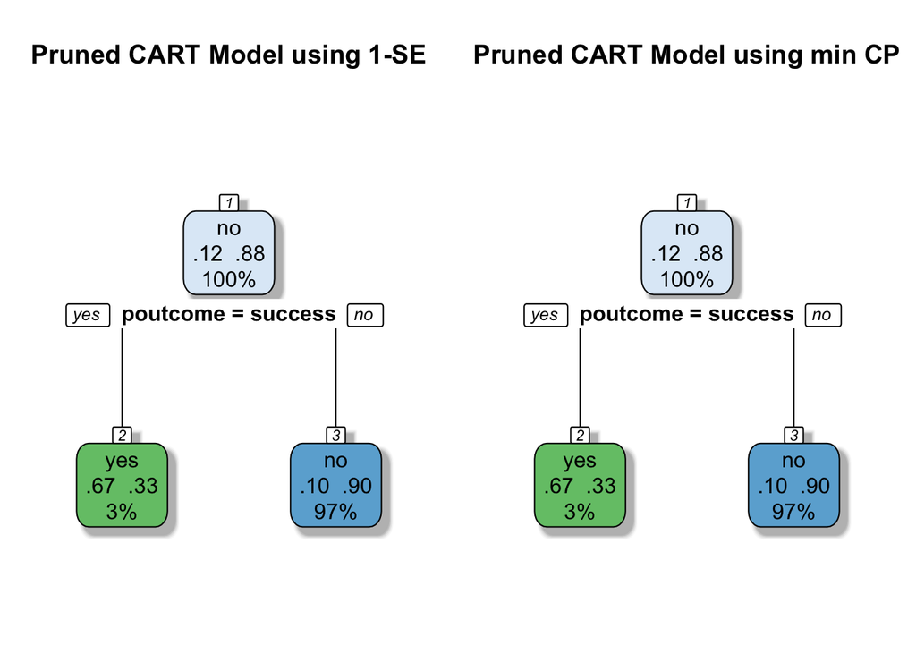

```r
# Find the optimal cp value that minimizes cross-validated error
min.cp <- tree.model$cptable[which.min(tree.model$cptable[,"xerror"]),"CP"]
#min.cp
# Prune the tree using the optimal cp
pruned.tree.1SE <- prune(tree.model, cp = 0.032)
pruned.tree.min <- prune(tree.model, cp = min.cp)


#manual 1-SE Rule Check
#cp_table <- tree.model$cptable
#min_xerror <- min(cp_table[,"xerror"])
#se_1se <- min_xerror + cp_table[which.min(cp_table[,"xerror"]), "xstd"]

# Get the smallest CP where xerror ≤ (min + 1SE)
#cp_1se <- cp_table[which(cp_table[,"xerror"] <= se_1se)[1], "CP"]
#cp_1se
# Now prune
#pruned.tree.1SE <- prune(tree.model, cp = cp_1se)


# Set up plotting area for two side-by-side plots
par(mfrow = c(1, 2))  # 1 row, 2 columns
# Visualize the pruned tree based on 1SE
plt_1SE<-rpart.plot(pruned.tree.1SE,
           extra = 104, # check the help document for more information
           # color palette is a sequential color scheme that blends green (G) to blue (Bu)
           box.palette = "GnBu",
           branch.lty = 1,
           shadow.col = "gray",
           nn = TRUE,
            main = "Pruned CART Model using 1-SE")

# Visualize the pruned tree based on min CP
plt_minCP<-rpart.plot(pruned.tree.min,
           extra = 104, # check the help document for more information
           # color palette is a sequential color scheme that blends green (G) to blue (Bu)
           box.palette = "GnBu",
           branch.lty = 1,
           shadow.col = "gray",
           nn = TRUE,
            main = "Pruned CART Model using min CP")
```

```r
# Reset layout
par(mfrow = c(1, 1))
```

From **Figure 4.2**, we see that both approaches seem identical simplified tree and indicate the only decision node to be the feature poutcome (Outcome of the previous marketing campaign = yes) is the most important predictor meaning whether a customer subscribed before is the strongest predictor of future subscription. However, the proportion of yes = 12% and no = 88% represents a class imbalance in the root node. In the left node (poutcome = success), proportion of yes = 67% and no = 33%. These are the customers likely to subscribe again thus prior positive experience yields increased trust. The right node (poutcome not equal to success: proportion of yes = 10% and proportion of no = 90%). This group was less likely to subscribe.Though the final pruned tree is simple, it is easy to interpret and may avoid overfitting since the pruned tree is based on cross-validation. The consistency in results in both strategies suggests that the additional splits in the original tree did not significantly improve model accuracy, and poutcome alone is a strong predictor.

## 4.3 Bagging: Predicting Term Deposit

In this section, we will explore the use of ensemble learning technique - Bagging. Bagging builds on a single decision tree (like CART which can be sensitive to small changes leading to over fitting). As a result, bagging uses multiple bootstrap samples from the training data to build a separate model on each sample and then aggregates predictions. In our dataset, where customer features such as job type, past campaign outcome, and financial status can vary widely, Bagging will help avoid overfitting and improve generalization to new customers.

We will use expand.grid in R to a dataset of the hyperparameters to be tuned for bagging including the following: nbagg: Number of bootstrap samples (trees), control: Parameters for the base learner (rpart in this case), minsplit: Minimum number of observations in a node before splitting, maxdepth: Maximum depth of the tree and cp: Complexity parameter.

```r
#incorporating BAGGING
library(ipred)
library(pander)


# Create a grid of hyperparameter combinations
hyper.grid <- expand.grid(
  nbagg = c(25, 50, 100),
  minsplit = c(5, 10, 20),
  maxdepth = c(5, 10, 20),
  cp = c(0.01, 0.001)
)
# Initialize a results data frame
results <- data.frame() # store values of tuned hyperparameters
best.accuracy <- 0      # store accuracy
best.params <- list()   # store best values of hyperparameter

# Loop through each hyperparameter combination
for(i in 1:nrow(hyper.grid)) {
  # Get current hyperparameters
  params <- hyper.grid[i, ]

  # Set rpart control parameters
  rpart.control <- rpart.control(
    minsplit = params$minsplit,
    maxdepth = params$maxdepth,
    cp = params$cp
  )

  # Train bagging model
  bag.model <- bagging(
    y ~ .,
    data = train.data,
    nbagg = params$nbagg,
    coob = TRUE,
    control = rpart.control
  )

  # Make predictions: default cut-off 0.5
  preds <- predict(bag.model, newdata = test.data)

  # Calculate accuracy
  cm <- confusionMatrix(preds, test.data$y)
  accuracy <- cm$overall["Accuracy"]

  # Store results
  results <- rbind(results, data.frame(
    nbagg = params$nbagg,
    minsplit = params$minsplit,
    maxdepth = params$maxdepth,
    cp = params$cp,
    Accuracy = accuracy
  ))

  # Update best parameters if current model is better
  if(accuracy > best.accuracy) {
    best.accuracy <- accuracy
    best.params <- params
  }

  # Print progress
  #cat("Completed", i, "of", nrow(hyper.grid), "combinations\n")
}
#pander(best.params)

pander(as.data.frame(best.params), caption = "Bagging: Best Hyperparameters Selected via Grid Search")
```

Bagging: Best Hyperparameters Selected via Grid Search

|  | nbagg | minsplit | maxdepth | cp |
| --- | --- | --- | --- | --- |
| **14** | 50 | 10 | 10 | 0.01 |

The best-performing model was obtained using 50 trees, a minimum split size of 10, a maximum depth of 10, and a complexity parameter (cp) of 0.01. These tuned hyperparameters will be used in the final bagging classification model in the next step to get confusion matrix from which we will calculate performance measures.

```r
# Set rpart control with best parameters
best.control <- rpart.control(
  minsplit = best.params$minsplit,
  maxdepth = best.params$maxdepth,
  cp = best.params$cp
)

# Train final model
final.bag.model <- bagging(
  y ~ .,
  data = train.data,
  nbagg = best.params$nbagg,
  coob = TRUE,
  control = best.control
)

# Evaluate on test set
final.preds <- predict(final.bag.model, newdata = test.data)
final.cm <- confusionMatrix(final.preds, test.data$y)
final.cm$table
```

```
          Reference
Prediction  yes   no
       yes   20   14
       no   136 1186
```

The above confusion matrix is from the Bagging classification used on the test data to predict term deposit with a a default cut-off probability. Next, we will use random forests to predict term deposit and then we will compare these approaches to the CART classification and base logistic regression model.

We will fit a random forest model using custom tuned hyperparameters via 5-fold cross-validation, such as the number of decision trees, maximum tree depth, and minimum samples required to split a node and evaluate different combinations of the hyperparameters in our bank dataset. Classification effectiveness will be based on ROC-AUC and confusion matrices. The hyperparameters will include - mtry: Number of variables randomly sampled as candidates at each split, ntree: Number of trees to grow, nodesize: Minimum size of terminal nodes, and maxnodes: Maximum number of terminal nodes trees can have.

```r
library(randomForest)
library(caret)
library(pROC)


data <- bank_updt[, c("y", "season", "balance_quantile", "age_quantile", "job", "marital", "education","contact", "poutcome","previous",
                           "default", "pdays" , "day","campaign", "housing" , "loan")]

set.seed(123)
train.idx <- createDataPartition(data$y, p = 0.7, list = FALSE)
train.datarf <- data[train.idx, ]
test.datarf <- data[-train.idx, ]

# cross-validation setting
k = 5
train.size <- dim(train.datarf)[1]  # training data size
fold.size <- floor(train.size/k)  # fold size

##
tune.grid <- expand.grid(
  mtry = c(2, 3, 4, 5),
  ntree = c(100, 300, 500),
  nodesize = c(1, 3, 5, 10),
  maxnodes = c(5, 10, 20, NULL)
)
### store hyperparameters and avg of cv AUC
results <- data.frame()
best.auc <- 0.5         # place-holder of AUC, 0.5 = random guess
best.hyp.params <- list()   # update the hyperparameter list according to the best auc

##
data$y <- factor(data$y, levels = c("no", "yes"))  # Make "yes" the positive class
for (i in 1:nrow(tune.grid)){
  current.tune.params <- tune.grid[i, ]  # subset of DATA FRAME!!
  cv.auc <- rep(0,k)
  ##
  for (j in 1:k){
      cv.id <- (1 + (j-1)*fold.size):(j*fold.size)
      cv.train <- train.datarf[-cv.id, ]
      cv.valid <- train.datarf[cv.id, ]
      ##
       rf.cv <- randomForest(
                   y ~ .,
                   data = cv.train,
                   mtry = current.tune.params$mtry,
                   ntree = current.tune.params$ntree,
                   nodesize = current.tune.params$nodesize,
                   maxnodes = current.tune.params$maxnodes)
       ##
       prob.cv <- predict(rf.cv, cv.valid, type = "prob")[, "yes"]
       cv.auc[j] <- auc(roc(cv.valid$y, prob.cv))
      }
      ##
      # Average RMSE across folds
      avg.auc <- mean(cv.auc)
      ##
      # Store results: the data frame defined to store combinations of hyperparameters
      # and the resulting mean RMSEs from cross-validation
      results <- rbind(results, data.frame(
                   mtry = current.tune.params$mtry,
                   ntree = current.tune.params$ntree,
                   nodesize = current.tune.params$nodesize,
                   maxnodes = current.tune.params$maxnodes,
                   auc = avg.auc))

     # Update best parameters if current model is better
     if(avg.auc > best.auc) {
           best.auc <- avg.auc
           best.hyp.params <- current.tune.params }

}
#pander(data.frame(cbind(best.hyp.params,best.auc)))    # resulting tuned hyperparameters

pander(data.frame(cbind(best.hyp.params,best.auc)), caption = "Random Forest: Best Hyperparameters Selected via Grid Search")
```

Random Forest: Best Hyperparameters Selected via Grid Search

|  | mtry | ntree | nodesize | maxnodes | best.auc |
| --- | --- | --- | --- | --- | --- |
| **142** | 3 | 500 | 10 | 20 | 0.6679 |

Using a grid search and 5-fold cross-validation, we identified the optimal hyperparamters that yield the highest predictive performance for the RF model and the best combination was made up of mtry = 3: the model considered 3 randomly selected features at each split, ntree = 500 indicating 500 decision trees were grown, providing a stable ensemble estimate, nodesize = 10: each terminal node had a minimum of 10 observations and maxnodes = 20: trees were restricted to a maximum of 20 terminal nodes. This combination resulted in AUC of 0.6679 across the validation folds: a moderate ability to discriminate subscribers from non-subscribers.

Next, we train the final model on these parameters and evaluate the model.

```r
final.rf.cls <- randomForest(
      y ~ .,
      data = train.datarf,
      ntree = best.hyp.params$ntree,
      mtry = best.hyp.params$mtry,
      nodesize = best.hyp.params$nodesize,
      maxnodes = current.tune.params$maxnodes,
      importance = TRUE
     )

test.pred <- predict(final.rf.cls, test.datarf)
test.prob <- predict(final.rf.cls, test.datarf, type = "prob")
rf.roc <- roc(test.datarf$y, test.prob[, "yes"])
test.auc <- auc(rf.roc)
#confusionMatrix(test.pred, test.data$diabetes)
#test.auc
```

The Random Forest AUC from the tuned paramters = 0.6944044. The tuned Random Forest model achieved an AUC of 0.6944, indicating that the model has moderate ability to discriminate between clients who will subscribe to a term deposit and those who will not. Next, we see the mean decrease in accuracy - The most important variables by this metric are poutcome, day, season, pdays, and previous and mean decrease in Gini - poutcome and pdays again stand out as the top contributors.

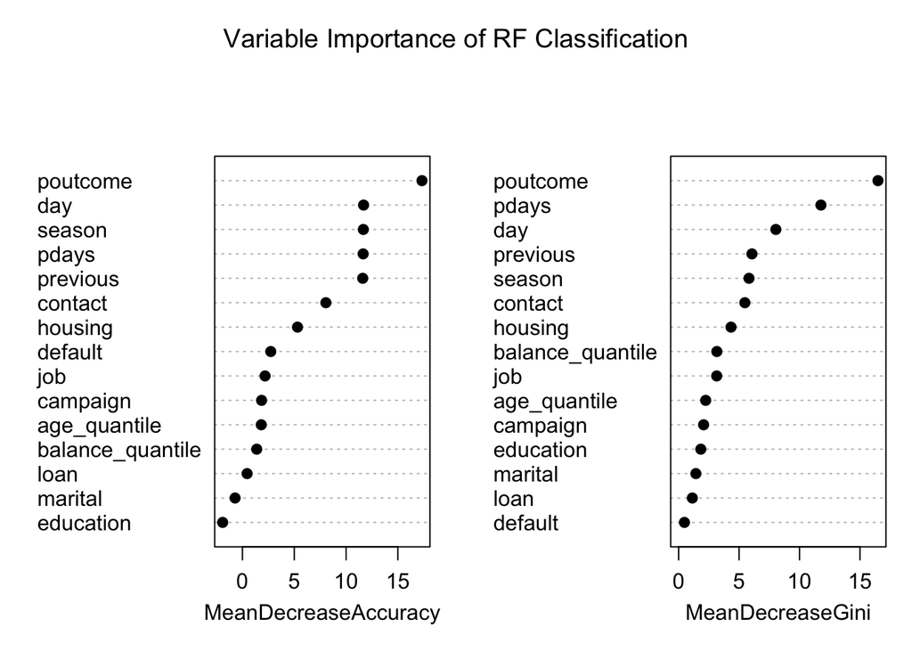

```r
# Variable Importance
varImpPlot(final.rf.cls, pch = 19, main = "Variable Importance of RF Classification" )
```

## 4.4 Global Performance with ROC

Next, we will evaluate the global performance of the predictive performance of these models in our analysis. We employed Receiver Operating Characteristic (ROC) curves and the Area Under the Curve (AUC) metrics since they provide a comprehensive assessment of model ability to classify the target using trade-off between sensitivity (true positive rate) and specificity (true negative rate) across all possible classification thresholds. ROC is used since it is useful when comparing different classification models and also unaffected by class imbalance.

We will compare the performance of logistic regression and pruned CART models (both 1-SE and minimum CP), Bagging and Random Forest using their respective ROC curves and AUC values to determine which model most effectively distinguishes between customers who subscribed to a term deposit and those who did not.

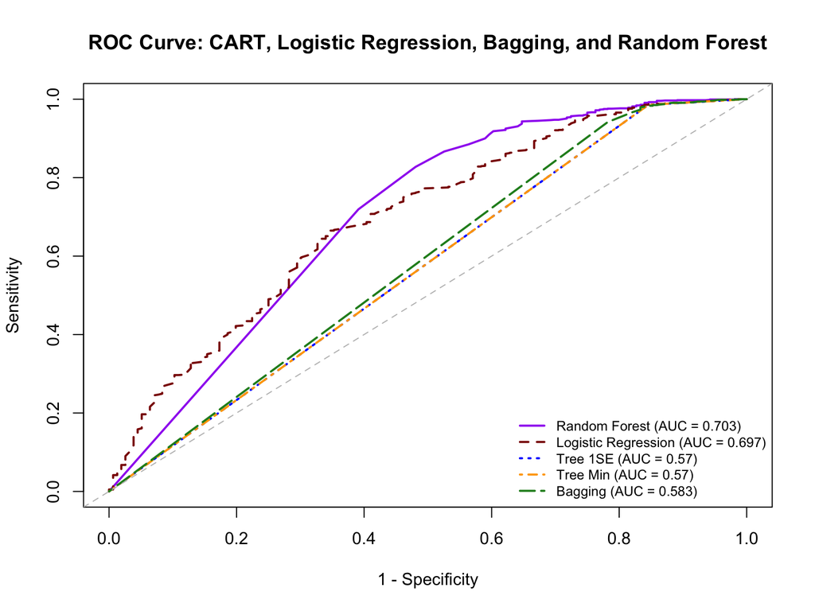

Figure 4.3: ROC and ACU comparaison of Pruned Initial CART Models, Bagging and Random Forest with Logistic regression

```r
 # Make predictions on the test set
pred.label.1SE <- predict(pruned.tree.1SE, test.data, type = "class") # default cutoff 0.5
pred.prob.1SE <- predict(pruned.tree.1SE, test.data, type = "prob")[,2]
##
pred.label.min <- predict(pruned.tree.min, test.data, type = "class") # default cutoff 0.5
pred.prob.min <- predict(pruned.tree.min, test.data, type = "prob")[,2]


# For Bagging
pred.prob.bag <- predict(final.bag.model, newdata = test.data, type = "prob")[, 2]


# For Random Forest
pred.prob.rf <- predict(final.rf.cls, newdata = test.data, type = "prob")[, 2]




# Confusion matrix
conf_matrix_mincp <- confusionMatrix(pred.label.min, test.data$y, positive = "yes")
conf_matrix_1se<-confusionMatrix(pred.label.1SE, test.data$y, positive = "yes")




########################
###  logistic regression
#names(train.data)

logit.fit <- glm(y ~ ., data = train.data, family = binomial)
AIC.logit <- step(logit.fit, direction = "both", trace = 0)
pred.logit <- predict(AIC.logit, test.data, type = "response")

# ROC curve and AUC
roc.tree.1SE <- roc(test.data$y, pred.prob.1SE)
roc.tree.min <- roc(test.data$y, pred.prob.min)
roc.logit <- roc(test.data$y, pred.logit)

roc.bag <- roc(test.data$y, pred.prob.bag)
roc.rf <- roc(test.data$y, pred.prob.rf)
##
### Sen-Spe
tree.1SE.sen <- roc.tree.1SE$sensitivities
tree.1SE.spe <- roc.tree.1SE$specificities
#
tree.min.sen <- roc.tree.min$sensitivities
tree.min.spe <- roc.tree.min$specificities
#
logit.sen <- roc.logit$sensitivities
logit.spe <- roc.logit$specificities


bag.sen <- roc.bag$sensitivities
bag.spe <- roc.bag$specificities

rf.sen <- roc.rf$sensitivities
rf.spe <- roc.rf$specificities



## AUC
auc.tree.1SE <- roc.tree.1SE$auc
auc.tree.min <- roc.tree.min$auc
auc.logit <- roc.logit$auc
auc.bag <- roc.bag$auc
auc.rf <- roc.rf$auc


### comment:command+shift+C
# plot(1-logit.spe, logit.sen,
#      xlab = "1 - specificity",
#      ylab = "sensitivity",
#      col = "darkred",
#      type = "l",
#      lty = 1,
#      lwd = 2,
#      main = "ROC: CART and Logistic Regressopm")
# lines(1-tree.1SE.spe, tree.1SE.sen,
#       col = "blue",
#       lty = 1,
#       lwd = 2)
# lines(1-tree.min.spe, tree.min.sen,
#       col = "orange",
#       lty = 2,
#       lwd = 2)
#
# # Add Bagging
# lines(1 - bag.spe, bag.sen, col = "forestgreen", lty = 3, lwd = 2)
# # Add Random Forest
# lines(1 - rf.spe, rf.sen, col = "purple", lty = 4, lwd = 2)
#
# abline(0,1, col = "skyblue3", lty = 2, lwd = 2)
# legend("bottomright", c("Logistic", "Tree 1SE", "Tree Min", "Bagging", "Random Forest"),
#        lty = c(1,1,1), lwd = rep(1,3),
#        col = c("red", "blue", "orange", "forestgreen", "purple"),
#        bty="n",cex = 0.8)
# ## annotation - AUC
# text(0.8, 0.46, paste("Logistic AUC: ", round(auc.logit,4)), cex = 0.8)
# text(0.8, 0.4, paste("Tree 1SE AUC: ", round(auc.tree.1SE,4)), cex = 0.8)
# text(0.8, 0.34, paste("Tree Min AUC: ", round(auc.tree.min,4)), cex = 0.8)
#
# text(0.8, 0.30, paste("Bagging AUC: ", round(auc.bag,4)), cex = 0.8)
# text(0.8, 0.25, paste("Random Forest AUC: ", round(auc.rf,4)), cex = 0.8)



# Set up ROC plot
plot(1 - rf.spe, rf.sen,
     type = "l", lwd = 2, lty = 1, col = "purple",
     xlab = "1 - Specificity", ylab = "Sensitivity",
     main = "ROC Curve: CART, Logistic Regression, Bagging, and Random Forest")

# Add other models
lines(1 - logit.spe, logit.sen, col = "darkred", lwd = 2, lty = 2)   # Logistic
lines(1 - tree.1SE.spe, tree.1SE.sen, col = "blue", lwd = 2, lty = 3)   # Tree 1SE
lines(1 - tree.min.spe, tree.min.sen, col = "orange", lwd = 2, lty = 4) # Tree Min
lines(1 - bag.spe, bag.sen, col = "forestgreen", lwd = 2, lty = 5)     # Bagging

# Add diagonal reference line
abline(0, 1, col = "grey", lty = 2)

# Add legend
legend("bottomright",
       legend = c(
         paste0("Random Forest (AUC = ", round(auc.rf, 3), ")"),
         paste0("Logistic Regression (AUC = ", round(auc.logit, 3), ")"),
         paste0("Tree 1SE (AUC = ", round(auc.tree.1SE, 3), ")"),
         paste0("Tree Min (AUC = ", round(auc.tree.min, 3), ")"),
         paste0("Bagging (AUC = ", round(auc.bag, 3), ")")
       ),
       col = c("purple", "darkred", "blue", "orange", "forestgreen"),
       lwd = 2, lty = 1:5, cex = 0.8, bty = "n")
```

**Figure 4.3** shows five models: Logistic Regression, CART Tree pruned at 1-SE, and CART Tree pruned at minimum CP—compare, Bagging and Random Forest in terms of their ability to distinguish between customers who do and do not subscribe to term deposits.

### 4.4.1 Logistic Regresson versus CART Models via ROC Curve

The Logistic Regression (AUC = 0.6973) performs better than both tree-based models, with the ROC curve bending away from the diagonal indicating moderate discriminating ability. This means the model does a reasonable job distinguishing between yes and no cases. Both pruned tree models (1-SE and min CP) have identical AUC values of 0.5698, indicating that they perform only slightly better but with their curves so close to the diagonal line, they have limited predictive power. The logistic model performs better overall because it does a better job of correctly identifying both subscribers and non-subscribers at different decision points, compared to the decision tree models and has better global predictive power.

### 4.4.2 Overall Performance Comparison via ROC Curve

The ROC curve above ( **Figure 4.3**) shows a comparative assessment of five classification models—Logistic Regression, CART (1-SE and min CP), Bagging, and Random Forest—used to predict customer subscription to term deposits in the bank dataset. The performance of each model is measured by its Area Under the Curve (AUC):

- Random Forest achieved the highest AUC (0.7026), indicating the best overall discriminatory ability among all models.
- Logistic Regression followed closely with an AUC of 0.6973, suggesting a strong performance thought it is simple and has linearity limitation.
- Bagging achieved a moderate AUC (0.5828), outperforming both CART models, but did not out perform Random Forest or Logistic Regression.
- CART (1-SE and min CP) performed similarly, both yielding an AUC of 0.5698, reflecting relatively weaker predictive power.

Ensemble methods like Random Forest and Bagging enhanced predictive accuracy, with Random Forest showing the greatest improvement, possibly due to its ability to reduce variance and model complex interactions.

The Logistic model remained a competitive benchmark given its interpretability and lower computational cost.The CART models, though interpretable, underperformed, in a way showing the benefit of model complexity and ensemble learning for this classification. The analysis has highlighted the strength of ensemble models, particularly Random Forest, in handling nonlinear patterns and class imbalance present in real-world financial data.

## 4.5 Optimal Cut-off Probability

In classification models, predictions are typically based on estimated probabilities with a default threshold of 0.5 used to assign classified groups. However, relying on this default threshold may not produce the best results especially in situations where the classes are imbalanced or when the consequences of misclassifying one class are more severe than the other.

To address this, we will determine an optimal cut-off probability ( threshold that minimizes a custom misclassification cost function or maximizes model performance metrics (accuracy, sensitivity, specificity, or cost-efficiency). We will use Youden’s Index for maximizing balanced sensitivity and specificity, and also, a Cost-Based threshold that prioritized minimizing financial loss from misclassifications. These optimal cutoffs should then be applied to the test set to evaluate each model under practical and balanced conditions but this will be outside the scope of this work.

We calculate and visualize the optimal threshold that best distinguishes subscribers from non-subscribers in the bank marketing dataset via the Youden and cost function approaches.

```r
library(pROC)

# Predict probabilities for each model
pred.prob.logit <- predict(AIC.logit, train.data, type = "response")
pred.prob.1SE   <- predict(pruned.tree.1SE, train.data, type = "prob")[, 2]
pred.prob.min   <- predict(pruned.tree.min, train.data, type = "prob")[, 2]
pred.prob.bag   <- predict(final.bag.model, newdata = train.data, type = "prob")[, 2]
pred.prob.rf    <- predict(final.rf.cls, newdata = train.data, type = "prob")[, 2]

#Cost-Based Function:
find_cost_based_cutoff <- function(prob, true_labels, cost_fp = 5, cost_fn = 20, grid_points = 1000) {
  cutoff_seq <- seq(0, 1, length.out = grid_points)
  cost <- numeric(length(cutoff_seq))

  for (i in seq_along(cutoff_seq)) {
    pred_label <- ifelse(prob > cutoff_seq[i], "yes", "no")
    FN <- sum(pred_label == "no" & true_labels == "yes", na.rm = TRUE)
    FP <- sum(pred_label == "yes" & true_labels == "no", na.rm = TRUE)
    cost[i] <- cost_fp * FP + cost_fn * FN
  }

  optimal_cutoff <- cutoff_seq[which.min(cost)]
  return(optimal_cutoff)
}

#youden function
find_youden_cutoff <- function(prob, true_labels) {
  roc_obj <- roc(true_labels, prob)
  youden_idx <- roc_obj$sensitivities + roc_obj$specificities - 1
  best_idx <- which.max(youden_idx)
  optimal_cutoff <- roc_obj$thresholds[best_idx]
  return(optimal_cutoff)
}


#apply function to models
# Cost-Based Optimal Cutoffs
cost_cutoff_logit <- find_cost_based_cutoff(pred.prob.logit, train.data$y)
cost_cutoff_1SE   <- find_cost_based_cutoff(pred.prob.1SE,   train.data$y)
cost_cutoff_min   <- find_cost_based_cutoff(pred.prob.min,   train.data$y)
cost_cutoff_bag   <- find_cost_based_cutoff(pred.prob.bag,   train.data$y)
cost_cutoff_rf    <- find_cost_based_cutoff(pred.prob.rf,    train.data$y)

# Youden's Index Optimal Cutoffs
youden_cutoff_logit <- find_youden_cutoff(pred.prob.logit, train.data$y)
youden_cutoff_1SE   <- find_youden_cutoff(pred.prob.1SE,   train.data$y)
youden_cutoff_min   <- find_youden_cutoff(pred.prob.min,   train.data$y)
youden_cutoff_bag   <- find_youden_cutoff(pred.prob.bag,   train.data$y)
youden_cutoff_rf    <- find_youden_cutoff(pred.prob.rf,    train.data$y)


library(knitr)

cutoff_summary <- data.frame(
  Model = c("Logistic Regression", "Tree 1SE", "Tree MinCP", "Bagging", "Random Forest"),
  Cost_Based_Cutoff = round(c(cost_cutoff_logit, cost_cutoff_1SE, cost_cutoff_min, cost_cutoff_bag, cost_cutoff_rf), 4),
  Youden_Cutoff = round(c(youden_cutoff_logit, youden_cutoff_1SE, youden_cutoff_min, youden_cutoff_bag, youden_cutoff_rf), 4)
)

kable(cutoff_summary, caption = "Optimal Cutoff Thresholds for Each Model")
```

Table 4.2: Optimal Cutoff Thresholds for Each Model

| Model | Cost_Based_Cutoff | Youden_Cutoff |
| --- | --- | --- |
| Logistic Regression | 1.0000 | 0.8729 |
| Tree 1SE | 0.9009 | 0.6150 |
| Tree MinCP | 0.9009 | 0.6150 |
| Bagging | 1.0000 | 0.9900 |
| Random Forest | 0.0120 | 0.0010 |

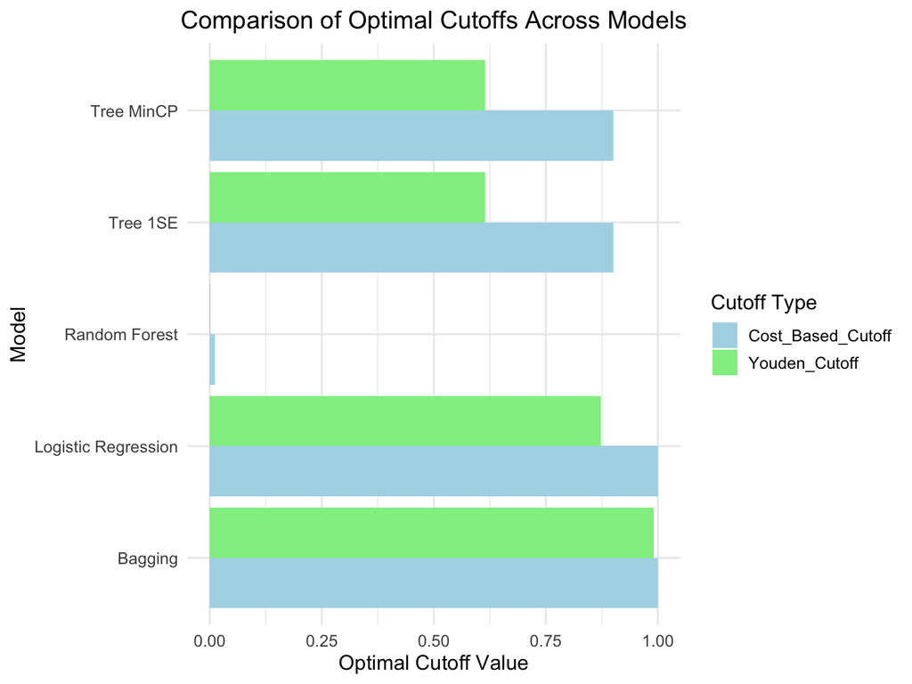

Figure 4.4: Optimal Cutoff Thresholds for Each Model

```r
#plot cut offs
# Reshape to long format
cutoff_long <- pivot_longer(cutoff_summary,
                             cols = c(Cost_Based_Cutoff, Youden_Cutoff),
                             names_to = "CutoffType",
                             values_to = "CutoffValue")

# Plot
ggplot(cutoff_long, aes(x = Model, y = CutoffValue, fill = CutoffType)) +
  geom_bar(stat = "identity", position = "dodge") +
  coord_flip() +
  scale_fill_manual(values = c("Cost_Based_Cutoff" = "lightblue", "Youden_Cutoff" = "lightgreen")) +
  labs(
    title = "Comparison of Optimal Cutoffs Across Models",
    x = "Model",
    y = "Optimal Cutoff Value",
    fill = "Cutoff Type"
  ) +
  theme_minimal(base_size = 13) +
  theme(plot.title = element_text(hjust = 0.5))
```

```r
# plot distribuiotn of probablitlities used to determine optimal cut off values in a histogram

# # 1. Create a dataframe with predicted probabilities from all models
# predicted_probs_df <- data.frame(
#   Logistic = pred.prob.logit,     # Logistic Regression
#   Tree_1SE = pred.prob.1SE,        # Tree pruned by 1-SE
#   Tree_MinCP = pred.prob.min,      # Tree pruned by minimum CP
#   Bagging = pred.prob.bag,         # Bagging model
#   RandomForest = pred.prob.rf      # Random Forest model
# )
#
# # 2. Reshape into long format for ggplot
# predicted_probs_long <- predicted_probs_df %>%
#   pivot_longer(cols = everything(),
#                names_to = "Model",
#                values_to = "Predicted_Probability")
#
# # 3. Plot
# ggplot(predicted_probs_long, aes(x = Predicted_Probability, fill = Model)) +
#   geom_histogram(position = "identity", alpha = 0.5, bins = 30) +
#   scale_fill_brewer(palette = "Set1") +
#   theme_minimal(base_size = 13) +
#   labs(
#     title = "Distribution of Predicted Probabilities Across Models",
#     subtitle = "Comparison: Logistic, CART Trees, Bagging, and Random Forest",
#     x = "Predicted Probability",
#     y = "Count",
#     fill = "Model"
#   ) +
#   theme(plot.title = element_text(hjust = 0.5),
#         plot.subtitle = element_text(hjust = 0.5))
#
# ggplot(predicted_probs_long, aes(x = Predicted_Probability, fill = Model)) +
#   geom_histogram(alpha = 0.7, bins = 30, color = "black") +
#   facet_wrap(~Model, scales = "free") +
#   theme_minimal(base_size = 13) +
#   labs(
#     title = "Predicted Probability Distributions by Model",
#     x = "Predicted Probability",
#     y = "Count"
#   )
```

# 5 Discussion

In our analysis, we investigated factors influencing client subscription to term deposits using machine learning models including CART decision trees (with pruning), logistic regression, bagging, and random forests. We compared the models’ performance using ROC curves, AUC values, and optimal classification thresholds determined using Youden’s index and cost-based functions for the practical bank data solutions.

Cutoff analysis showed that the cost-based optimal thresholds were often much higher (closer to 1.0) than the default 0.5. This showed that the models did better at higher probabilities while the Youden’s index provided lower thresholds for a balance in trade-off between false positives and false negatives. The choice between these thresholds should depend on the organization’s operational priorities and constraints however. In the bank business strategy, the cost approach may be better but if the goal is to identify as many potential subscribers as possible, then the Youden threshold may be more effective. Our evaluation highlights the importance of going beyond default thresholds (such as 0.5) and selecting decision rules that align with business goals. These obtained optimal cut-off should be used to predtict on test data but this beyond the current analysis.

Overall, ensemble models such as bagging and random forests captured more complex data patterns, while CART and logistic regression provided more interpretable.

# 6 Limitations

In the presence of the insights obtained, there are several limitations as well that should be noted. First, the target variable showed skewness toward non-subscribers which may bias the models toward the larger class even with tuning. Optimal cutoffs may be sensitive to cost functions and Youden’s index. There was data noise where feature variable balance showed skewness that could impact model stability even with transformation. Feature engineering options may also influence model behavior. And finally, whilw random forests performed well, their interpretability is limited compared to single decision trees or logistic regression.

```r
#The tuned tree at optimal complexity parameter  = `r tree.tuned$bestTune `  appears too simple though the feature (poutcome) is logically a strong predictor since a past campaign that was successful is a likely a strong predictor but this model may also be underfitted. The model predicts 'yes' with a probablity of 67% and 'no' with a probability of 90%.
tune.grid <- expand.grid(cp = seq(0.001, 0.05, by = 0.005))

train.control <- trainControl(method = "cv", number = 5)

tree.tuned <- train(y ~ ., data = train.data,
                    method = "rpart",
                    trControl = train.control,
                    tuneGrid = tune.grid,
                    parms = list(split = "gini"),
                    metric = "Accuracy")  # Or "Kappa", or custom metric

print(tree.tuned$bestTune)

#rpart.plot(tree.tuned$finalModel, type = 2, extra = 104,
           #fallen.leaves = TRUE, main = "Optimized CART Model")
```

[output not shown]